# Lecture 04: Logistic Regression with Summary Data

Module on Logistic Regression

# Lecture Goals

- Review of Logistic Regression
- Working with “summary data” for Logistic Regression
- Review the details of working with Categorical predictor variables

# Logistic regression from summarized data

With binary response data, the response variable can be presented in one of two ways: by either a variable in a dataset corresponding to each observations success or failure (typically 0’s and 1’s, FALSE and TRUE, or two categories), or a matrix with two columns specifying the number of success and failure for given predictor variables. The latter sometimes is the way data appears in studies where all the predictors are categorical – this is known as “summary data” or “aggregated data”. This is the case when the data are supplied in a contingency table.

## Revisit the Youth Risk Behavorial Survey

The Youth Risk Behavior Surveillance System (YRBSS) is a public health initiative by the Center for Disease Control and Prevention (CDC) that monitors six key categories of health-risk behaviors among high school students. The YRBSS is conducted biannually in the spring semester and has been conducted regularly since 1991. We will look at a subset of the survey from 2023.

Specifically, we will look to determine if demographic variables are associated with wether a high school was bullied on school property in the preceding 12 months.

[figure not shown]

**Sources:** Data: (Centers for Disease Control and Prevention 2024). Concept and Clipart: (Brener et al. 2024).

```r
yrbss <- read_csv("https://tjfisher19.github.io/data/cdc_yrbss_2023.csv",
                  show_col_types=FALSE)
```

In our introduction to statistical odds, we looked at the odds of a student being bullied predicted by their grade level. We built the following contingency table using `xtabs()`.

```r
xtabs(~ Grade + Bullied_at_School, data=yrbss)
```

```
            Bullied_at_School
Grade          No  Yes
  10th grade 3819  992
  11th grade 3579  760
  12th grade 3066  537
  9th grade  3619 1233
```

To demonstrate some *new* data processing techniques and to fit a logistic model using summary data, we will take that contingency table and build a `data.frame`.

```r
xtab_out <- xtabs(~ Grade + Bullied_at_School, data=yrbss)
## First row
xtab_out[1,]
## Second column
xtab_out[,2]
## Row names
rownames(xtab_out)
```

```
  No  Yes
3819  992
10th grade 11th grade 12th grade  9th grade
       992        760        537       1233
[1] "10th grade" "11th grade" "12th grade" "9th grade"
```

We use the output from `xtabs()` to build a `data.frame`. Extract the column entries using the matrix notation `[,]` for each variable and use the row names to dictate the Grade level. We also turn the Grade variable into a factor variable.

```r
yrbss_summary_df <- data.frame(
  Bullied = xtab_out[,2],      # Yes column
  Not_Bullied = xtab_out[,1],  # No column
  Grade = rownames(xtab_out)
) |>
  mutate(Grade = factor(Grade,
                        levels=c("9th grade", "10th grade", "11th grade", "12th grade") ) )
```

We fit the logistic model. Since the data are in a summary or aggregated format, we use the `cbind()` function to “bind” the column reporting the number of successes (called `Bullied`) with the column reporting the number of failures (called `Not_Bullied`).

```r
fit_yrbss_summary <- glm(cbind(Bullied, Not_Bullied) ~ Grade,
                         data=yrbss_summary_df,
                         family=binomial(link="logit"))
```

**Coding Note**

The `cbind()` function takes a sequence of vectors and *binds* them by columns. There is also an `rbind()` function, both are built into R. If looking to ‘bind’ multiple `data.frame` objects together, we recommend `bind_rows()` in the `tidyverse`.

We will compare that fitted model to one using the original which has an observation for each student (rather than summarized across four rows):

```r
## Brief data processing
yrbss <- yrbss |>
    mutate(Grade = factor(Grade,
                        levels=c("9th grade", "10th grade", "11th grade", "12th grade") ),
         Bullied = Bullied_at_School=="Yes")

## Fit the model
fit_yrbss_original <- glm(Bullied ~ Grade,
                          data=yrbss,
                          family=binomial(link="logit"))
```

Now we compare the two models:

```r
fit_yrbss_summary
```

```
Call:  glm(formula = cbind(Bullied, Not_Bullied) ~ Grade, family = binomial(link = "logit"),
    data = yrbss_summary_df)

Coefficients:
    (Intercept)  Grade10th grade  Grade11th grade  Grade12th grade
        -1.0767          -0.2713          -0.4728          -0.6654

Degrees of Freedom: 3 Total (i.e. Null);  0 Residual
Null Deviance:      164.8
Residual Deviance: 2.409e-12    AIC: 41.41
```

```r
fit_yrbss_original
```

```
Call:  glm(formula = Bullied ~ Grade, family = binomial(link = "logit"),
    data = yrbss)

Coefficients:
    (Intercept)  Grade10th grade  Grade11th grade  Grade12th grade
        -1.0767          -0.2713          -0.4728          -0.6654

Degrees of Freedom: 17604 Total (i.e. Null);  17601 Residual
Null Deviance:      17620
Residual Deviance: 17460    AIC: 17470
```

The model coefficients are the same! Both versions of the data result in the same estimated logistic regression equation – this should be expected, it is ultimately the same observations and the same underlying relationship!

However, there are differences in the two fitted models. The summary data has very little deviance, and the fitted model has no meaningful residual deviance. Whereas the model based on the original data shows substantially more residual deviance.

## Understanding Summarized Data

In the previous section we fit logistic regression models to two different representations of the same data. Both resulted in the same fitted model, but the measures of deviance are different. The reason **why** has to do with two key ideas from the field of statistics:

- Statistics is the study of variability.
- When performing statistical modeling, we are trying to model that variability observed in the data.

To understand at a deeper level, let’s work with a contrived example. Suppose an experiment was conducted to model some numeric response variable $Y$ using predetermined covariate terms $X$ and the resulting data is:

```r
contrived_df <- data.frame(
  x = c(1, 1, 1, 1, 6, 6, 6, 6, 9, 9, 9, 9),
  y = c(3, 5, 7, 9, 6, 7, 8, 9, 9, 11, 13, 15)
)
```

Since there are only 3 unique $X$ values, suppose you decide to consider the “average $Y$” across each of the $X$ values.

```r
contrived_summarized <- contrived_df |>
  group_by(x) |>
  summarize(y = mean(y))
```

A visual of the original dataset and the summarized version is provided here:

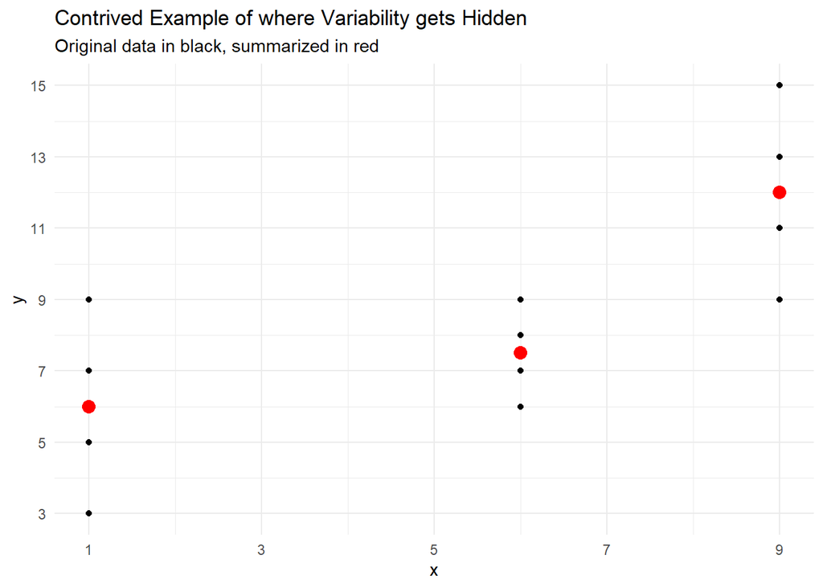

```r
ggplot(contrived_df) +
  geom_point(data=contrived_summarized, aes(x=x,y=y), color="red", size=3.5) +
  geom_point(aes(x=x, y=y) ) +
  scale_x_continuous(breaks=seq(1,9,2), minor_breaks=seq(2,8,2) ) +
  scale_y_continuous(breaks=seq(1,15,2), minor_breaks=seq(2,14,2) ) +
  labs(title="Contrived Example of where Variability gets Hidden",
       subtitle="Original data in black, summarized in red") +
  theme_minimal()
```

```r
lm(y ~ x, data=contrived_df)
lm(y ~ x, data=contrived_summarized)
```

```
Call:
lm(formula = y ~ x, data = contrived_df)

Coefficients:
(Intercept)            x
     4.7449       0.7041


Call:
lm(formula = y ~ x, data = contrived_summarized)

Coefficients:
(Intercept)            x
     4.7449       0.7041
```

The exact same model is fit using both datasets. Yet other important metrics about the models differ:

```r
bind_rows(
  glance(lm(y ~ x, data=contrived_df) ) |>
    mutate(Model = "With Original Data"),
  glance(lm(y ~ x, data=contrived_summarized) ) |>
    mutate(Model = "With Summarized Data")
) |>
  select(Model, sigma, RSq = r.squared, SSE=deviance) |>
  kable(digits=4, caption="Comparison of Model's Variability Measures")
```

Comparison of Model’s Variability Measures

| Model | sigma | RSq | SSE |
| --- | --- | --- | --- |
| With Original Data | 2.4130 | 0.5266 | 58.2245 |
| With Summarized Data | 1.8183 | 0.8305 | 3.3061 |

With the summarized data, we have implicitly modeled some of the variability by taking the average for each unique $X$; thus we have reduced the overall error in the linear model. This effectively makes the model based on the summary data look *better* than it really is: the residual standard error is smaller, it has a higher R-squared and the SSE is drastically smaller. In regression, these changes could greatly influence all inferential procedures (the $F$-test, conditional $t$-test, prediction intervals, etc…).

When fitting a logistic regression using summarized data, some of the underlying variability has already been explained during the aggregation or summarization process. So the deviance measures are smaller than when working with the original observations.

Measures like Pseudo R-squared have less interpretation with summarized data as it is expected that residual deviance will be quite small. Likewise, **do not compare *goodness-of-fit* measures for logistic models when one was built with summary data and another with the original observations**.

Fortunately, the **deviance** still has use when working with summarized data in logistic regression. We can still compare the residual deviance to its degrees of freedom as a measure of the model’s appropriateness. If the model is well fit we would expect the **Residual Deviance $\approx$ Degrees of Freedom**. The example above demonstrates an extreme case of this property as both the Residual Deviance and Degrees of Freedom are zero.

This measure of fit can also be assessed by comparing the ratio of $\text{Residual Deviance}/\text{Degrees of Freedom}$ to the value of 1. If the ratio greatly exceeds 1, this indicates overdispersion in the data and a very poor model fit; whereas values near one indicate a good fit.

A summarized data example with with multiple predictor variables is provided in the next section.

**Note**

In the example of bullying by Grade level, we have fit a *perfect* or *saturated* model, which is why the residual deviance is zero with zero degrees of freedom.

# Example: The Donner-Reed Party

As a second example of working with summary data, we look at data from one of the sadder tidbits of American history.

By 1846, more and more people were picking up and moving west to states like Oregon, Utah and California. George Donner was the organizer of the Donner Party expedition. His advertisement in the Springfield, Illinois Gazette invited anyone who wanted to travel to California for free land to join him. Many families eager for the promise of land answered Donner’s call to pursue the American dream.

On April 16, 1846, a group of 87 (90 by some sources) men, women and children left Illinois and began the long journey to California with the hope of arriving before the winter snows began in the Sierra Nevada Mountains.

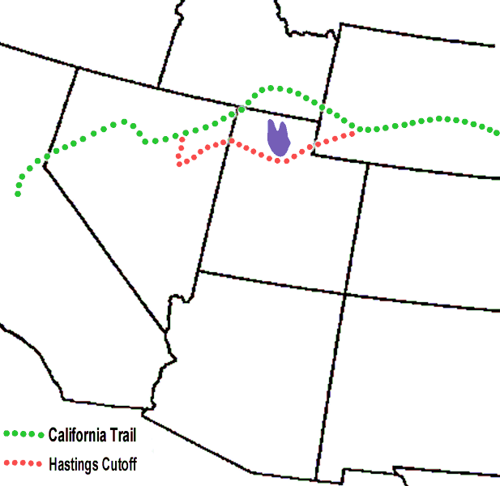

The Donner Party made a fateful error when they decided to try an untested shortcut known as the Hastings Cutoff. Normally, travelers went north around the Great Salt Lake into Idaho before turning south again back into Nevada. However, a new route promising a straighter and faster passage south of the Great Salt Lake was suggested by land promoter Lansford Hastings in his book, *The Emigrants’ Guide to Oregon and California*. As it turns out, Hastings had never actually traveled this route and had no idea if wagons could handle the trail.

In actuality, the cutoff was not accessible for wagons and cattle, and was many miles longer. The “shortcut” put the Donner Party weeks behind schedule, and when they reached the eastern side of the Sierra Nevada Mountains in late October, an early blizzard hit and snowed them in on Truckee Lake. It would turn out to be one of the worst winters in the history of the Sierra Nevadas where the snowpack can pile up to 30 feet deep. For five months, the Donner Party was stranded with no food, and little-to-no chance for escape or rescue. They butchered the cattle they had, but many of the cows had wandered off or died in the snow. They soon turned to boiling leather shoestrings and hides for food, and as members of the party succumbed to the cold, some of the survivors tragically resorted to cannibalism of their friends and family.

The present data set contains actual information about survival counts by age and biological sex for the 87 members of the Donner party based on various records.

**Sources:** Data: (Grayson 1990). Concept: (Study.com 2023). Map: (Wikimedia Commons contributors 2005).

## Input and Exploration

The first step is to input the data and look at its form.

```r
donner <- read_csv("https://tjfisher19.github.io/data/donnerparty.csv",
                   show_col_types=FALSE)
kable(donner, caption="Donner-Reed Party Dataset")
```

Donner-Reed Party Dataset

| Age | Sex | Survived | Died |
| --- | --- | --- | --- |
| Child | Male | 14 | 10 |
| Child | Female | 14 | 5 |
| Adult | Male | 9 | 20 |
| Adult | Female | 10 | 5 |

The data are not presented as 87 rows (one per subject) - here the data is presented in a four row table of summary values. The response information is summarized across two columns, where one column contains a summary total count of “successes” for the given row, and the other column contains a summary total count of “failures” for the given row. In this problem, there are only two age groups and two sexes, so we have four rows of success/failure counts, one for each combination.

Fit the logistic regression using this data format, modeling the probability of survival for Donner Party members based on their age and sex:

```r
donner.fit <- glm(cbind(Survived, Died) ~ Age + Sex,
                  data=donner,
                  family=binomial(link=logit))
```

## Analysis of Fitted Model

For the sake of review, we will apply many of the inference procedures from the previous lecture.

**Is $P(survival)$ predicted by age and biological sex?**

We can determine this through the “whole-model” test for significance. Recall, with logistic regression we perform a $\chi^2$ likelihood ratio test (an analogue to the whole model $F$-test in *Normal* linear regression).

```r
## First we fit the so-called "null" model
donner.null <- glm(cbind(Survived, Died) ~ 1,
                   data=donner,
                   family=binomial(link=logit))

## Then compare the two models using anova()
anova(donner.null, donner.fit)
```

```
Analysis of Deviance Table

Model 1: cbind(Survived, Died) ~ 1
Model 2: cbind(Survived, Died) ~ Age + Sex
  Resid. Df Resid. Dev Df Deviance Pr(>Chi)
1         3    10.5226
2         1     0.7055  2    9.817 0.007384 **
---
Signif. codes:  0 '***' 0.001 '**' 0.01 '*' 0.05 '.' 0.1 ' ' 1
```

With a $\chi^2$ statistic of 9.817 on 2 degrees of freedom ($p$-value=0.007384), we have evidence that the probability of survival for members of the Donner Party is significantly predicted by the model with both Age and Sex.

**How well is $P(survival)$ predicted by age and biological sex?**

Here, we have a question asking “how well” or “how much”. This resembles the a goodness-of-fit question from regression. We can look at a Pseudo $R^2$ with some caution to answer this question since the data was provided in summary form.

```r
(1 - 0.7055/10.5226)*100
```

```
[1] 93.29538
```

Based on Pseudo $R^2$, the model with Age and Sex is explaining about 93.3% of the deviance in the probability of survival for members of the Donner party.

## Individual Coefficients Impacts

Begin with an interpretation of the individual parameters here. Make a mental note that both predictor variables are categorical and each has two levels as this impacts our interpretation. Before looking at the fitted model output, let’s recall the fitted model in all its forms. First, in terms of log-odds:
$$\log\left(\frac{p}{1-p}\right) = \hat{\beta}_0 + \hat{\beta}_1 I(\text{Child}) + \hat{\beta}_2 I(\text{Male})$$
which in terms of odds is:
$$\frac{p}{1-p} = \exp\left\{\hat{\beta}_0 + \hat{\beta}_1 I(\text{Child}) + \hat{\beta}_2 I(\text{Male})\right\} = \exp\left\{\hat{\beta}_0\right\} \times \exp\left\{\hat{\beta}_1 I(\text{Child})\right\} \times \exp\left\{\hat{\beta}_2 I(\text{Male})\right\}$$
and lastly, as a probability:
$$p = \frac{\exp\left\{\hat{\beta}_0\right\} \times \exp\left\{\hat{\beta}_1 I(\text{Child})\right\} \times \exp\left\{\hat{\beta}_2 I(\text{Male})\right\}}{1 + \exp\left\{\hat{\beta}_0\right\} \times \exp\left\{\hat{\beta}_1 I(\text{Child})\right\} \times \exp\left\{\hat{\beta}_2 I(\text{Male})\right\}}$$

Now the fitted model output

```r
summary(donner.fit)
```

```
Call:
glm(formula = cbind(Survived, Died) ~ Age + Sex, family = binomial(link = logit),
    data = donner)

Coefficients:
            Estimate Std. Error z value Pr(>|z|)
(Intercept)   0.4382     0.4403   0.995   0.3196
AgeChild      0.8467     0.4562   1.856   0.0635 .
SexMale      -1.0981     0.4767  -2.303   0.0213 *
---
Signif. codes:  0 '***' 0.001 '**' 0.01 '*' 0.05 '.' 0.1 ' ' 1

(Dispersion parameter for binomial family taken to be 1)

    Null deviance: 10.52256  on 3  degrees of freedom
Residual deviance:  0.70555  on 1  degrees of freedom
AIC: 20.272

Number of Fisher Scoring iterations: 4
```

- `(Intercept)` – $\hat{\beta}_0$ = 0.43824: Recalling that categorical predictor variables are used, the intercept will include some factor levels. Here, the intercept is Adult Females based on the other coefficients. An adult female in the Donner party has a log-odds of surviving of 0.43824.

  Re-expressing as odds: `exp(coef(donner.fit)[1])` which results in 1.54998. That is, the odds an adult female in the Donner party survive are 1.54998.
- `AgeChild` – $\hat{\beta_1}$ = 0.84666: The `AgeChild` predictor here is expressed as an indicator variable of being a **child** (*i.e.*, $I(\text{Child})=1$). Since the parameter estimate is positive, it tells us that the log odds of survival for children is *larger* than for adults. Specifically, the log-odds a child survives will increase by 0.84666 compared to an adults.

  Re-expressing as odds: `exp(coef(donner.fit)[2])` results in a value of 2.33185. That is, the odds of a child surviving is 2.33185 times that of an adult surviving.
- `SexMale` – $\hat{\beta_2}$ = -1.0980982: The `SexMale` predictor here is expressed as an indicator variable of being a **male**. Since the parameter estimate is negative, it tells us that the log odds of survival for males is *smaller* than for females.

  Re-expressing as odds: `exp(coef(donner.fit)[3])`. The odds of a male surviving is 0.3335 times that of an female surviving. Note that you can “flip” this and re-express from the female perspective by taking reciprocals of the odds: The odds for a female is 2.99846 times as likely to survive as compared to a male.

### Inference on Coefficients

From an inferential perspective we could make confidence intervals:

```r
exp(confint(donner.fit))
```

```
                2.5 %    97.5 %
(Intercept) 0.6623553 3.7980662
AgeChild    0.9623487 5.8065603
SexMale     0.1268340 0.8324674
```

- We are 95% confident that the odds a female adult survives is between 0.662 and 3.798.
- We can be 95% confident that a child is 0.962 to 5.807 times as likely to survive as an adult.
  - Note this interval includes the value 1, which corresponds to a log-odds of 0.
  - We’ll statistically test the significance of the variable in a moment.
- We can be 95% confident that a male is 0.127 to 0.832 times as likely to survive as compared to a female.

We can statistically test for the significance of the predictor variables:

```r
drop1(donner.fit, test="LRT")
```

```
Single term deletions

Model:
cbind(Survived, Died) ~ Age + Sex
       Df Deviance    AIC    LRT Pr(>Chi)
<none>      0.7055 20.272
Age     1   4.2194 21.786 3.5138  0.06086 .
Sex     1   6.2732 23.840 5.5677  0.01829 *
---
Signif. codes:  0 '***' 0.001 '**' 0.01 '*' 0.05 '.' 0.1 ' ' 1
```

Based on these results, we could argue that the `Age` variable is not significantly predicting the log-odds of surviving when the `Sex` variable is already included in the model.

## Predicted Probabilities

Data with strictly categorical predictors makes predictions of probabilities viable, but we need to be careful with the algebra. We can explicitly find all the probabilities for all factor levels using the fitted model. Recall the fitted model in all its forms again. First, in terms of log-odds:
$$\log\left(\frac{p}{1-p}\right) = \hat{\beta}_0 + \hat{\beta}_1 I(\text{Child}) + \hat{\beta}_2 I(\text{Male})$$
which in terms of odds is:
$$\frac{p}{1-p} = \exp\left\{\hat{\beta}_0 + \hat{\beta}_1 I(\text{Child}) + \hat{\beta}_2 I(\text{Male})\right\} = \exp\left\{\hat{\beta}_0\right\} \times \exp\left\{\hat{\beta}_1 I(\text{Child})\right\} \times \exp\left\{\hat{\beta}_2 I(\text{Male})\right\}$$
and lastly, as a probability:
$$p = \frac{\exp\left\{\hat{\beta}_0\right\} \times \exp\left\{\hat{\beta}_1 I(\text{Child})\right\} \times \exp\left\{\hat{\beta}_2 I(\text{Male})\right\}}{1 + \exp\left\{\hat{\beta}_0\right\} \times \exp\left\{\hat{\beta}_1 I(\text{Child})\right\} \times \exp\left\{\hat{\beta}_2 I(\text{Male})\right\}}$$

Now we can calculate all predicted probabilities with some careful bookkeeping.

**An Adult Female**

This corresponds to the $\hat{\beta}_0$ value in the fitted model since $I(\text{Child}) = I(\text{Male}) = 0$, so the log-odds of an adult female surviving are 0.4382, correspond to odds 1.55 which corresponds to probability 0.6078.

**An Adult Male**

Here, the `SexMale` variable $I(\text{Male})$ will take on the value one and $I(\text{Child})=0$, so the log-odds are $\hat{\beta}_0 + \hat{\beta}_2$ which corresponds to 0.4382 + -1.0981 = -0.6599. In terms of odds this is 1.55 $\times$ 0.3335 = 0.5169. And lastly, the probability is 0.3408.

**A Female Child**

Here, $I(\text{Child})=1$ and $I(\text{Male})=0$, so the log-odds are $\hat{\beta}_0 + \hat{\beta}_1$ which corresponds to 0.4382 + 0.8467 = 1.2849 In terms of odds this is 1.55 $\times$ 2.3319 = 3.6143 and probability 0.7833.

### Using Code

Alternatively, and much easier, is to use the `predict()` function. We just need to be careful to remember which prediction corresponds to which combination of groups:

```r
predict(donner.fit, type="response")
```

```
        1         2         3         4
0.5465669 0.7832839 0.3407722 0.6078404
```

We can easily see how it correspond to the groups by appending these predictions to the data:

```r
donner |>
  mutate(`Predicted Probability of Surviving` = predict(donner.fit, type="response") ) |>
  kable(caption="Predicted Probabilities from Logistic Regression")
```

Predicted Probabilities from Logistic Regression

| Age | Sex | Survived | Died | Predicted Probability of Surviving |
| --- | --- | --- | --- | --- |
| Child | Male | 14 | 10 | 0.5465669 |
| Child | Female | 14 | 5 | 0.7832839 |
| Adult | Male | 9 | 20 | 0.3407722 |
| Adult | Female | 10 | 5 | 0.6078404 |

## References

Brener, Nancy D., Jonetta J. Mpofu, Kathleen H. Krause, Sherry Everett Jones, Jemekia E. Thornton, Zachary Myles, William A. Harris, et al. 2024. “Overview and Methods for the Youth Risk Behavior Surveillance System — United States, 2023.” *MMWR Supplements* 73 (4): 1–12. https://doi.org/10.15585/mmwr.su7304a1.

Centers for Disease Control and Prevention. 2024. “2023 Youth Risk Behavior Survey Data.” Atlanta, GA: CDC Website.

Grayson, Donald K. 1990. “Donner Party Deaths: A Demographic Assessment.” *Journal of Anthropological Research* 46 (3): 223–42.

Study.com. 2023. “The Donner Party: Facts & Summary.” https://study.com/academy/lesson/the-donner-party-facts-summary.html.

Wikimedia Commons contributors. 2005. “File:HastingsCutoff.gif.” Wikimedia Commons.